# Preliminaries and Rationale

The PH Housing dataset was selected for this project due to its relevance, granularity, and applicability to the Philippine real estate market. It contains structured data on residential properties, including both quantitative features such as the number of bedrooms, bathrooms, land area, and floor area, as well as geographic coordinates and corresponding property prices.

Using a localized dataset enables the development of a predictive model that reflects the actual characteristics and market conditions of the Philippines. The housing market in the Philippines has unique traits that distinguish it from other global regions. These include the distribution of urban and rural developments, variability in infrastructure quality, regional income disparities, and proximity-based valuation differences. Incorporating these local patterns into the model allows for more accurate and context-specific predictions.

Furthermore, the dataset provides latitude and longitude data, which supports geospatial feature engineering—an essential component for modeling property prices based on location. This geographic dimension enhances the model’s ability to learn spatial trends that influence market valuation.

Use Case: Predictive Modeling for Real Estate Pricing The primary objective of this machine learning project is to develop a regression model capable of predicting residential property prices based on key structural and locational attributes. This model can be deployed in several practical scenarios across the real estate ecosystem:

1. For Real Estate Agents and Property Sellers An automated price estimation tool enables agents and sellers to determine fair market prices for new listings. By minimizing overpricing or undervaluation, it supports strategic decision-making and increases the competitiveness of listed properties.
2. For Homebuyers The model provides immediate, data-driven estimates of property values, which aids buyers in budget assessment and negotiation. It reduces dependency on third-party valuation and speeds up the purchasing process.
3. For Online Real Estate Platforms Integrating this predictive capability into listing platforms can enhance user experience by suggesting prices during property submission, filtering options based on estimated market value, or ranking listings by value-to-price ratio.

```python
# Imports
import pandas as pd
import numpy as np
import matplotlib.pyplot as plt
import seaborn as sns
import warnings
from sklearn.model_selection import train_test_split, GridSearchCV
from sklearn.preprocessing import StandardScaler
from sklearn.linear_model import LinearRegression, Ridge, Lasso
from sklearn.ensemble import RandomForestRegressor
from sklearn.metrics import mean_squared_error, mean_absolute_error, r2_score
from sklearn.metrics.pairwise import euclidean_distances
from sklearn.cluster import KMeans
from geopy.geocoders import Nominatim

warnings.filterwarnings("ignore", category=UserWarning, module="sklearn")
```

```python
# Upload & Clean Dataset
df = pd.read_csv("PH_Housing.csv")
df = df.dropna(subset=['Price', 'Bedrooms', 'Bathrooms', 'Floor Area', 'Land Area', 'Latitude', 'Longitude'])
df
```

|  | HouseID | Description | Location | Price | Bedrooms | Bathrooms | Floor Area | Land Area | Latitude | Longitude |
| --- | --- | --- | --- | --- | --- | --- | --- | --- | --- | --- |
| 0 | 1 | Preselling 2-Storey Townhouses in Village East... | Santo Domingo, Cainta | 9500000.0 | 4.0 | 3.0 | 144.0 | 136.0 | 14.582341 | 121.118044 |
| 1 | 2 | Affordable House & Lot with Complete Amenities... | San Vicente, Santa Maria | 4400000.0 | 3.0 | 2.0 | 63.2 | 80.0 | 14.807715 | 121.002402 |
| 2 | 3 | 5BR 2-Storey House and Lot for Sale in Tarlac ... | Camella Tarlac Access Rd. Maliwalo, Tarlac | 7810000.0 | 5.0 | 3.0 | 100.0 | 110.0 | 15.477785 | 120.614075 |
| 4 | 5 | Futura Homes Zamboanga \| Amber 2BR Townhouse E... | Zambowood Rd. Boalan, Zamboanga | 3275000.0 | 2.0 | 1.0 | 40.3 | 78.4 | 6.948389 | 122.114889 |
| 6 | 7 | 2BR 2-Storey Townhouse for Sale at Marytown Pl... | Santa Maria-San Jose Rd. Bulac, Santa Maria | 1800000.0 | 2.0 | 2.0 | 52.0 | 40.0 | 14.827975 | 121.000389 |
| ... | ... | ... | ... | ... | ... | ... | ... | ... | ... | ... |
| 1495 | 1496 | 5 Bedroom House and Lot for sale in Asisan, Ta... | Asisan, Tagaytay | 16000000.0 | 5.0 | 2.0 | 180.0 | 540.0 | 14.098639 | 120.908756 |
| 1496 | 1497 | For Sale: Affordable 3 Bedroom Townhouse at Se... | Pooc, Talisay | 4500000.0 | 3.0 | 2.0 | 90.0 | 55.0 | 10.238378 | 123.824438 |
| 1497 | 1498 | Modern 4BR House with Swimming Pool in AFPOVAI... | Western Bicutan, Taguig | 45000000.0 | 4.0 | 3.0 | 370.0 | 200.0 | 14.509527 | 121.038024 |
| 1498 | 1499 | Modern House w/ Overlooking Mountain view in A... | Antipolo | 78000000.0 | 5.0 | 5.0 | 822.0 | 556.0 | 14.587197 | 121.175925 |
| 1499 | 1500 | [04847-CEB-124] Townhouse for sale in Brgy Tuy... | Lot 69 Block 2 Pueblo El Grande Subdivision Ph... | 5500000.0 | 2.0 | 4.0 | 112.0 | 120.0 | 10.369595 | 123.984277 |

1323 rows × 10 columns

# Feature Engineering: Clustering + Proximity

To enhance the model’s ability to interpret location-based influences on housing prices, two additional geographic features were engineered: cluster-based location grouping and a proximity density score.

- First, the latitude and longitude coordinates of each property were used to perform K-Means clustering, grouping locations into 10 spatial clusters. Each property was assigned a corresponding cluster label, which was subsequently one-hot encoded into binary categorical features. This process allows the model to learn location-based price patterns at a macro level without directly interpreting raw coordinates.
- Second, a location density score was computed using the average Euclidean distance from each property to all others (after scaling the coordinates). The score was defined as the inverse of the average distance, so that properties surrounded by many nearby listings (i.e., in denser areas) would receive higher scores. This metric captures the intensity of local development, which often correlates with pricing due to factors like accessibility, infrastructure, and demand concentration.

```python
coords = df[['Latitude', 'Longitude']]
kmeans = KMeans(n_clusters=10, random_state=42)
df['LocationCluster'] = kmeans.fit_predict(coords)

# One-hot encode the cluster
df = pd.get_dummies(df, columns=['LocationCluster'], prefix='Cluster')

# Add proximity score
coords_scaled = StandardScaler().fit_transform(df[['Latitude', 'Longitude']])
distance_matrix = euclidean_distances(coords_scaled)
df['LocationDensityScore'] = 1 / (1 + distance_matrix.mean(axis=1))
```

# Train-Test Split

Following the feature engineering stage, the dataset was prepared for supervised learning through a structured train-test split and standardized preprocessing.A set of predictor features was defined by combining structural attributes (Bedrooms, Bathrooms, Floor Area, Land Area) with geographic inputs (Latitude, Longitude), the engineered LocationDensityScore, and the one-hot encoded location clusters.

This transformation centers each feature around a mean of zero and scales it to unit variance, which is essential for algorithms sensitive to feature magnitude (such as Ridge and Lasso regression). Both training and test features were scaled using the parameters learned from the training set alone, ensuring that no information from the test set was leaked into the training process.

This preprocessing step establishes a clean, normalized foundation for model development and evaluation, enhancing the comparability and performance of subsequent machine learning models.

```python
base_features = ['Bedrooms', 'Bathrooms', 'Floor Area', 'Land Area', 'Latitude', 'Longitude', 'LocationDensityScore']
cluster_features = [col for col in df.columns if col.startswith('Cluster_')]
final_features = base_features + cluster_features

df = df.dropna(subset=final_features + ['Price'])
X = df[final_features]
y = df['Price']

X_train, X_test, y_train, y_test = train_test_split(X, y, test_size=0.3, random_state=42)

scaler = StandardScaler()
X_train_scaled = pd.DataFrame(scaler.fit_transform(X_train), columns=X_train.columns)
X_test_scaled = pd.DataFrame(scaler.transform(X_test), columns=X_test.columns)
```

# Machine Learning Process (Tuned + Untuned)

This section involves the development, training, and performance evaluation of several regression models aimed at predicting residential property prices based on engineered features. The process encompasses both untuned (default) models and their corresponding hyperparameter-optimized versions.

1. Evaluation Procedure
- A reusable evaluation function was defined to compute and report four key regression performance metrics:
  - Mean Squared Error (MSE): Measures the average of the squared differences between predicted and actual prices.
  - Root Mean Squared Error (RMSE): The square root of MSE, providing a metric in the same unit as the target variable.
  - Mean Absolute Error (MAE): Represents the average magnitude of errors without considering their direction.
  - R-squared (R²): Indicates the proportion of variance in the target variable explained by the model.
- Each model is fit on the training set and evaluated using the test set. The computed metrics are stored in a results dictionary for subsequent analysis and visualization.
2. Untuned Model Evaluation
- Four baseline regression models were initially trained using their default hyperparameters:
  - Linear Regression: Serves as the baseline model, using ordinary least squares.
  - Ridge Regression: A linear model with L2 regularization to penalize large coefficients and reduce overfitting.
  - Lasso Regression: Incorporates L1 regularization, which can shrink some coefficients to zero, performing implicit feature selection.
  - Random Forest Regressor: A non-linear ensemble learning method that uses multiple decision trees for improved accuracy and robustness.
- These untuned models provide reference performance levels and help identify the benefits of further optimization.
3. Hyperparameter Tuning and Grid Search
- To enhance predictive performance, a hyperparameter tuning process was applied to Ridge, Lasso, and Random Forest models using GridSearchCV, a brute-force search method that evaluates all combinations of specified parameter values through cross-validation.
  - Ridge Tuned: Tuned over a range of alpha values controlling the strength of L2 regularization.
  - Lasso Tuned: Tuned over alpha values affecting the degree of sparsity in the coefficients.
  - Random Forest Tuned: Tuned across multiple parameters including the number of trees (n_estimators), tree depth (max_depth), and minimum samples required for splits (min_samples_split).
- Each tuned model was evaluated using the same metrics as the untuned versions, allowing for direct performance comparison.
4. Comparative Insights
- By evaluating both untuned and tuned models within a unified framework, this approach enables comprehensive benchmarking. It highlights the impact of regularization, model complexity, and hyperparameter configuration on prediction accuracy. The combination of linear and non-linear models also provides insight into whether the target variable exhibits linear or more complex relationships with the input features.

```python
def evaluate_model(model, name, result_dict):
    model.fit(X_train_scaled, y_train)
    preds = model.predict(X_test_scaled)
    mse = mean_squared_error(y_test, preds)
    rmse = np.sqrt(mse)
    mae = mean_absolute_error(y_test, preds)
    r2 = r2_score(y_test, preds)
    result_dict[name] = {"MSE": mse, "RMSE": rmse, "MAE": mae, "R2": r2}
    print(f"\n{name}")
    print(f"MSE  : {mse:.2f}")
    print(f"RMSE : {rmse:.2f}")
    print(f"MAE  : {mae:.2f}")
    print(f"R²   : {r2:.4f}")

from sklearn.linear_model import Ridge, Lasso, LinearRegression
from sklearn.ensemble import RandomForestRegressor

results = {}

# Untuned models
untuned_models = {
    "Linear Regression": LinearRegression(),
    "Ridge": Ridge(),
    "Lasso": Lasso(max_iter=10000),
    "Random Forest": RandomForestRegressor(random_state=42)
}

print("Evaluating Untuned Models")
for name, model in untuned_models.items():
    evaluate_model(model, name, results)

# Tuned models
param_grids = {
    "Ridge - Tuned": {
        "model": Ridge(),
        "params": {"alpha": [0.01, 0.1, 1.0, 10.0, 100.0]}
    },
    "Lasso - Tuned": {
        "model": Lasso(max_iter=10000),
        "params": {"alpha": [0.001, 0.01, 0.1, 1.0]}
    },
    "Random Forest - Tuned": {
        "model": RandomForestRegressor(random_state=42),
        "params": {
            "n_estimators": [100, 200, 300],
            "max_depth": [10, 20, 30, 50, None],
            "min_samples_split": [2, 5, 8]
        }
    }
}

print("\n Tuning and Evaluating Models")
for name, cfg in param_grids.items():
    grid = GridSearchCV(cfg["model"], cfg["params"], cv=3, scoring='neg_mean_squared_error')
    grid.fit(X_train_scaled, y_train)
    best_model = grid.best_estimator_
    evaluate_model(best_model, name, results)
    print(f"Best Parameters for {name}: {grid.best_params_}")
```

```
Evaluating Untuned Models

Linear Regression
MSE  : 11661663836357916.00
RMSE : 107989183.89
MAE  : 26064053.18
R²   : 0.3833

Ridge
MSE  : 11656720376230450.00
RMSE : 107966292.78
MAE  : 25941589.06
R²   : 0.3836

Lasso
MSE  : 11661663475311134.00
RMSE : 107989182.21
MAE  : 26064047.26
R²   : 0.3833

Random Forest
MSE  : 9698598617954132.00
RMSE : 98481463.32
MAE  : 11498106.56
R²   : 0.4871

 Tuning and Evaluating Models

Ridge - Tuned
MSE  : 12153275242886654.00
RMSE : 110241894.23
MAE  : 23463652.98
R²   : 0.3573
Best Parameters for Ridge - Tuned: {'alpha': 100.0}

Lasso - Tuned
MSE  : 11661663475311134.00
RMSE : 107989182.21
MAE  : 26064047.26
R²   : 0.3833
Best Parameters for Lasso - Tuned: {'alpha': 1.0}

Random Forest - Tuned
MSE  : 9530982934866682.00
RMSE : 97626753.17
MAE  : 11573172.07
R²   : 0.4960
Best Parameters for Random Forest - Tuned: {'max_depth': 30, 'min_samples_split': 2, 'n_estimators': 300}
```

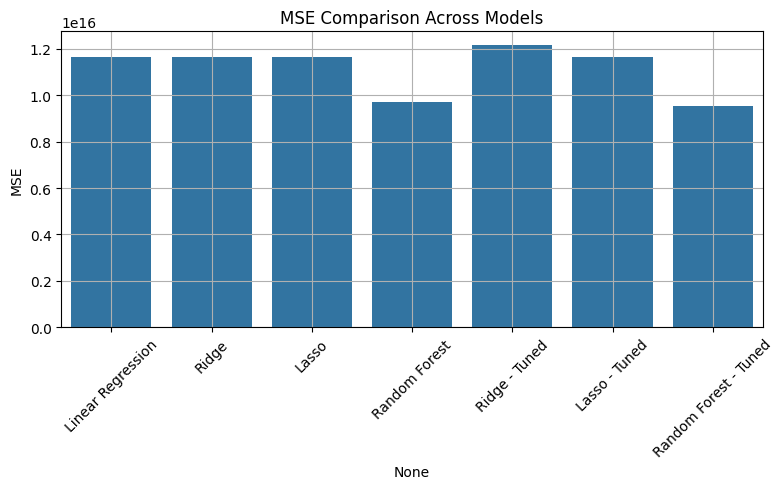

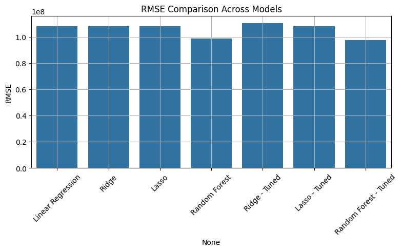

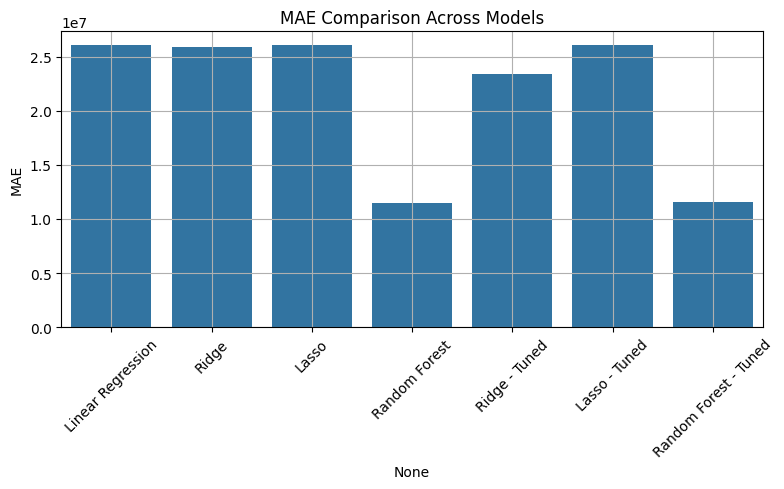

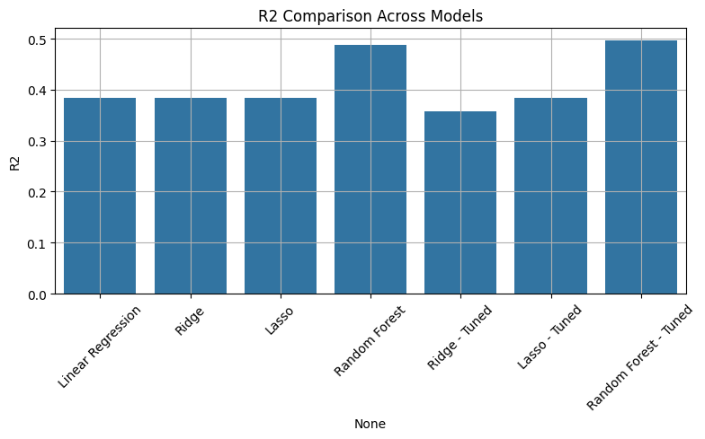

```python
# Performance Visualization
metrics_df = pd.DataFrame(results).T

def plot_metric(metric):
    plt.figure(figsize=(8, 5))
    sns.barplot(x=metrics_df.index, y=metrics_df[metric])
    plt.title(f"{metric} Comparison Across Models")
    plt.ylabel(metric)
    plt.xticks(rotation=45)
    plt.grid(True)
    plt.tight_layout()
    plt.show()

for metric in ['MSE', 'RMSE', 'MAE', 'R2']:
    plot_metric(metric)
```

The evaluation of both untuned and tuned machine learning models reveals distinct performance differences between linear models and non-linear ensemble methods in predicting housing prices based on structural and location-based features.

The untuned linear models—Linear Regression, Ridge, and Lasso—all yielded similar results, with R² scores clustered around 0.38. This indicates that these models explained only approximately 38% of the variance in property prices. Ridge Regression slightly outperformed the base linear model, demonstrating marginal improvement due to L2 regularization, which can help mitigate multicollinearity. Lasso Regression, which uses L1 regularization to enforce feature sparsity, produced results nearly identical to Linear Regression. This suggests that most of the input features were relevant, and the Lasso penalty did not result in substantial coefficient shrinkage.

In contrast, the untuned Random Forest Regressor achieved an R² of 0.4871, outperforming all linear models by a significant margin. The model reduced the Root Mean Squared Error (RMSE) from over ₱107 million (in the case of Linear Regression) to approximately ₱98 million, and lowered the Mean Absolute Error (MAE) from over ₱26 million to ₱11.5 million. These improvements underscore the Random Forest model’s ability to capture complex, non-linear interactions among features, especially those involving geographic clustering and proximity effects.

Hyperparameter tuning further refined these results. The tuned Ridge model, surprisingly, performed worse than its untuned counterpart. With an R² of 0.3573, it suffered from over-regularization due to the selected alpha=100.0, which likely suppressed informative feature contributions and led to underfitting. The tuned Lasso model exhibited no improvement, retaining the same performance as the untuned version. This suggests that Lasso’s regularization did not meaningfully alter model performance, likely because feature selection had already been adequately handled during preprocessing.

- n_estimators = 300 (more trees, enhancing generalization),
- max_depth = 30 (enabling greater model complexity), and
- min_samples_split = 2 (allowing deeper tree structures).

These hyperparameters allowed the model to more effectively learn from the available data without overfitting, yielding the most accurate predictions in the study.

This confirms that Random Forest models, both tuned and untuned, are significantly more effective than linear models in this context. The inclusion of spatial features and engineered location-based variables further enhanced performance. However, with the best model explaining just under 50% of the variance, there remains potential for further improvement through additional data, advanced spatial features, or alternative ensemble techniques such as Gradient Boosting or XGBoost.

# DEMO

```python
def predict_price_from_input(location_str, bedrooms, bathrooms, floor_area, land_area):
    from geopy.geocoders import Nominatim

    # Geocoding
    def get_geopy_longlat(address_str):
        geolocator = Nominatim(user_agent="https")
        try:
            location = geolocator.geocode(address_str)
            return location.latitude, location.longitude
        except:
            return -999, -999

    lat, long = get_geopy_longlat(location_str)

    # Validation: Geocoding failed
    if lat == -999 or long == -999:
        print("Failed to geocode location.")
        return

    # Validation: Check if location is within Philippine geographic bounds
    if not (4.38 <= lat <= 21.42 and 112.0 <= long <= 127.0):
        print(f"Location '{location_str}' is outside the bounds of the Philippines.")
        print(f"Received coordinates: ({lat:.5f}, {long:.5f})")
        return

    # Compute LocationDensityScore
    ref_coords_scaled = StandardScaler().fit_transform(df[['Latitude', 'Longitude']])
    user_coords_scaled = StandardScaler().fit(df[['Latitude', 'Longitude']]).transform([[lat, long]])
    user_distances = euclidean_distances(user_coords_scaled, ref_coords_scaled)
    location_density_score = float(1 / (1 + user_distances.mean()))

    # Predict cluster and build test input
    cluster_label = kmeans.predict(pd.DataFrame([[lat, long]], columns=['Latitude', 'Longitude']))[0]

    test_input = {
        "Bedrooms": bedrooms,
        "Bathrooms": bathrooms,
        "Floor Area": floor_area,
        "Land Area": land_area,
        "Latitude": lat,
        "Longitude": long,
        "LocationDensityScore": location_density_score
    }

    for col in [c for c in final_features if c.startswith("Cluster_")]:
        test_input[col] = 1 if col == f"Cluster_{cluster_label}" else 0

    test_df = pd.DataFrame([test_input])[final_features]
    test_scaled = scaler.transform(test_df)
    predicted_price = best_model.predict(test_scaled)[0]

    # Output
    print(f"Location: {location_str} ({lat:.5f}, {long:.5f})")
    print("Predicted House Price: ₱{:,.2f}".format(predicted_price))
```

```python
#Test the inputs
predict_price_from_input(
    location_str = "BGC Taguig", # Be specific in location "BGC Taguig", "Sampaloc Manila"
    bedrooms = 3,
    bathrooms = 1,
    floor_area = 48, #in Sqm
    land_area = 100.0 #in Sqm
)
```

```
Location: BGC Taguig (14.55520, 121.04235)
Predicted House Price: ₱7,118,238.38
```

```python
!jupyter nbconvert --execute --to html "/content/Applied_ML_Final_Exam.ipynb"
```

[output not shown]